# hw4_submit

# 3. Train Test split

```r
set.seed(12345)

test_set <- sample(1:nrow(tele_small), 0.2*nrow(tele_small))
tele_train <- tele_small[-test_set, ]
tele_test <- tele_small[test_set, ]

# upsample to balance the sample size for 0 and 1 values for yyes for train data
# set.seed(12345)
# library(groupdata2)
# tele_train <- upsample(tele_train, cat_col = "yyes")
# table(tele_train$yyes)

str(tele_train)
```

```
## 'data.frame':    1648 obs. of  54 variables:
##  $ age                         : num  0.148 0.272 0.247 0.136 0.148 ...
##  $ jobadmin.                   : num  0 0 1 1 0 0 1 0 0 1 ...
##  $ jobblue.collar              : num  1 0 0 0 1 0 0 0 1 0 ...
##  $ jobentrepreneur             : num  0 0 0 0 0 0 0 0 0 0 ...
##  $ jobhousemaid                : num  0 0 0 0 0 0 0 0 0 0 ...
##  $ jobmanagement               : num  0 0 0 0 0 0 0 0 0 0 ...
##  $ jobretired                  : num  0 0 0 0 0 0 0 1 0 0 ...
##  $ jobself.employed            : num  0 0 0 0 0 0 0 0 0 0 ...
##  $ jobservices                 : num  0 0 0 0 0 0 0 0 0 0 ...
##  $ jobstudent                  : num  0 0 0 0 0 0 0 0 0 0 ...
##  $ jobtechnician               : num  0 1 0 0 0 1 0 0 0 0 ...
##  $ jobunemployed               : num  0 0 0 0 0 0 0 0 0 0 ...
##  $ jobunknown                  : num  0 0 0 0 0 0 0 0 0 0 ...
##  $ maritalmarried              : num  0 1 1 0 1 0 0 1 1 1 ...
```

[output cut: 40 more lines]

```r
summary(tele_train)
```

```
##       age            jobadmin.      jobblue.collar   jobentrepreneur
##  Min.   :0.01235   Min.   :0.0000   Min.   :0.0000   Min.   :0.00000
##  1st Qu.:0.18519   1st Qu.:0.0000   1st Qu.:0.0000   1st Qu.:0.00000
##  Median :0.27160   Median :0.0000   Median :0.0000   Median :0.00000
##  Mean   :0.28806   Mean   :0.2488   Mean   :0.2191   Mean   :0.03459
##  3rd Qu.:0.37037   3rd Qu.:0.0000   3rd Qu.:0.0000   3rd Qu.:0.00000
##  Max.   :0.87654   Max.   :1.0000   Max.   :1.0000   Max.   :1.00000
##   jobhousemaid     jobmanagement       jobretired      jobself.employed
##  Min.   :0.00000   Min.   :0.00000   Min.   :0.00000   Min.   :0.00000
##  1st Qu.:0.00000   1st Qu.:0.00000   1st Qu.:0.00000   1st Qu.:0.00000
##  Median :0.00000   Median :0.00000   Median :0.00000   Median :0.00000
##  Mean   :0.02791   Mean   :0.07403   Mean   :0.04733   Mean   :0.03459
##  3rd Qu.:0.00000   3rd Qu.:0.00000   3rd Qu.:0.00000   3rd Qu.:0.00000
##  Max.   :1.00000   Max.   :1.00000   Max.   :1.00000   Max.   :1.00000
##   jobservices       jobstudent     jobtechnician    jobunemployed
##  Min.   :0.0000   Min.   :0.0000   Min.   :0.0000   Min.   :0.00000
##  1st Qu.:0.0000   1st Qu.:0.0000   1st Qu.:0.0000   1st Qu.:0.00000
##  Median :0.0000   Median :0.0000   Median :0.0000   Median :0.00000
##  Mean   :0.1062   Mean   :0.0182   Mean   :0.1632   Mean   :0.02002
##  3rd Qu.:0.0000   3rd Qu.:0.0000   3rd Qu.:0.0000   3rd Qu.:0.00000
##  Max.   :1.0000   Max.   :1.0000   Max.   :1.0000   Max.   :1.00000
##    jobunknown       maritalmarried   maritalsingle    maritalunknown
##  Min.   :0.000000   Min.   :0.0000   Min.   :0.0000   Min.   :0.0000000
##  1st Qu.:0.000000   1st Qu.:0.0000   1st Qu.:0.0000   1st Qu.:0.0000000
##  Median :0.000000   Median :1.0000   Median :0.0000   Median :0.0000000
##  Mean   :0.006068   Mean   :0.6117   Mean   :0.2694   Mean   :0.0006068
##  3rd Qu.:0.000000   3rd Qu.:1.0000   3rd Qu.:1.0000   3rd Qu.:0.0000000
##  Max.   :1.000000   Max.   :1.0000   Max.   :1.0000   Max.   :1.0000000
##  educationbasic.6y educationbasic.9y educationhigh.school educationilliterate
##  Min.   :0.00000   Min.   :0.0000    Min.   :0.0000       Min.   :0
##  1st Qu.:0.00000   1st Qu.:0.0000    1st Qu.:0.0000       1st Qu.:0
##  Median :0.00000   Median :0.0000    Median :0.0000       Median :0
##  Mean   :0.06493   Mean   :0.1432    Mean   :0.2306       Mean   :0
##  3rd Qu.:0.00000   3rd Qu.:0.0000    3rd Qu.:0.0000       3rd Qu.:0
##  Max.   :1.00000   Max.   :1.0000    Max.   :1.0000       Max.   :0
##  educationprofessional.course educationuniversity.degree educationunknown
##  Min.   :0.0000               Min.   :0.0000             Min.   :0.00000
##  1st Qu.:0.0000               1st Qu.:0.0000             1st Qu.:0.00000
##  Median :0.0000               Median :0.0000             Median :0.00000
##  Mean   :0.1274               Mean   :0.2888             Mean   :0.03944
```

[output cut: 43 more lines]

```
##  Max.   :0.60000   Max.   :1.00000   Max.   :1.0000      Max.   :1.00000
##   emp.var.rate    cons.price.idx   cons.conf.idx      euribor3m
##  Min.   :0.0000   Min.   :0.0000   Min.   :0.0000   Min.   :0.0000
##  1st Qu.:0.3333   1st Qu.:0.3406   1st Qu.:0.3389   1st Qu.:0.1610
##  Median :0.9375   Median :0.4844   Median :0.3766   Median :0.9574
##  Mean   :0.7264   Mean   :0.5339   Mean   :0.4272   Mean   :0.6761
##  3rd Qu.:1.0000   3rd Qu.:0.6988   3rd Qu.:0.6025   3rd Qu.:0.9810
##  Max.   :1.0000   Max.   :1.0000   Max.   :1.0000   Max.   :0.9830
##   nr.employed          yyes          pdaysdummy
##  Min.   :0.0000   Min.   :0.0000   Min.   :0.00000
##  1st Qu.:0.5123   1st Qu.:0.0000   1st Qu.:0.00000
##  Median :0.8597   Median :0.0000   Median :0.00000
##  Mean   :0.7690   Mean   :0.1056   Mean   :0.03155
##  3rd Qu.:1.0000   3rd Qu.:0.0000   3rd Qu.:0.00000
##  Max.   :1.0000   Max.   :1.0000   Max.   :1.00000
```

```r
# str(tele_test)
# summary(tele_test)
# table(tele_train$yyes)
```

# 4. Check na

```r
table(is.na(tele_small))
```

```
##
##  FALSE
## 111186
```

# 5. Models

## 5.1 Logistic Regression model

```r
log_model <- glm(yyes ~., data = tele_train, family = "binomial")
log_pred <- predict(log_model, tele_test, type="response")
log_pred_binary <- ifelse(log_pred >= 0.5, 1, 0)

library(caret)
confusionMatrix(as.factor(log_pred_binary), as.factor(tele_test$yyes), positive = "1")
```

```
## Confusion Matrix and Statistics
##
##           Reference
## Prediction   0   1
##          0 365  29
##          1   9   8
##
##                Accuracy : 0.9075
##                  95% CI : (0.8753, 0.9337)
##     No Information Rate : 0.91
##     P-Value [Acc > NIR] : 0.610414
##
##                   Kappa : 0.254
##
##  Mcnemar's Test P-Value : 0.002055
##
##             Sensitivity : 0.21622
##             Specificity : 0.97594
##          Pos Pred Value : 0.47059
##          Neg Pred Value : 0.92640
##              Prevalence : 0.09002
##          Detection Rate : 0.01946
##    Detection Prevalence : 0.04136
##       Balanced Accuracy : 0.59608
##
##        'Positive' Class : 1
##
```

## 5.2 KNN model

```r
# label and data split
KNN_train_label <- tele_train[ , 53]
KNN_train <- tele_train[ , -53]

KNN_test_label <- tele_test[ , 53]
KNN_test <- tele_test[ , -53]

# model
library(class)
knn_pred <- knn(train = KNN_train, test = KNN_test, cl = KNN_train_label, k = 40) # train data rows square root = k
summary(knn_pred)
```

```
##   0   1
## 411   0
```

```r
# evaluation
library(caret)
confusionMatrix(as.factor(knn_pred), as.factor(KNN_test_label), positive = "1")
```

```
## Confusion Matrix and Statistics
##
##           Reference
## Prediction   0   1
##          0 374  37
##          1   0   0
##
##                Accuracy : 0.91
##                  95% CI : (0.878, 0.9358)
##     No Information Rate : 0.91
##     P-Value [Acc > NIR] : 0.5436
##
##                   Kappa : 0
##
##  Mcnemar's Test P-Value : 3.252e-09
##
##             Sensitivity : 0.00000
##             Specificity : 1.00000
##          Pos Pred Value :     NaN
##          Neg Pred Value : 0.90998
##              Prevalence : 0.09002
##          Detection Rate : 0.00000
##    Detection Prevalence : 0.00000
##       Balanced Accuracy : 0.50000
##
##        'Positive' Class : 1
##
```

## 5.3 ANN model

```r
library(neuralnet)
```

```r
ann_model <- neuralnet(yyes ~., data = tele_train)
plot(ann_model)
ann_pred <- predict(ann_model, tele_test, type="response")
ann_pred_binary <- ifelse(ann_pred >= 0.5, 1, 0)

confusionMatrix(as.factor(ann_pred_binary), as.factor(tele_test$yyes), positive = "1")
```

```
## Confusion Matrix and Statistics
##
##           Reference
## Prediction   0   1
##          0 351  27
##          1  23  10
##
##                Accuracy : 0.8783
##                  95% CI : (0.8428, 0.9083)
##     No Information Rate : 0.91
##     P-Value [Acc > NIR] : 0.9874
##
##                   Kappa : 0.2195
##
##  Mcnemar's Test P-Value : 0.6714
##
##             Sensitivity : 0.27027
##             Specificity : 0.93850
##          Pos Pred Value : 0.30303
##          Neg Pred Value : 0.92857
##              Prevalence : 0.09002
##          Detection Rate : 0.02433
##    Detection Prevalence : 0.08029
##       Balanced Accuracy : 0.60439
##
##        'Positive' Class : 1
##
```

```r
# we need non-binary values for stack model for ANN and logi
```

## 5.4 Decision Tree model

```r
library(C50)
```

```r
DT_model <- C5.0(as.factor(yyes) ~., data = tele_train) # C5.0 models require a factor outcome
# plot(DT_model)
# summary(DT_model)

DT_pred <- predict(DT_model, tele_test)

confusionMatrix(as.factor(DT_pred), as.factor(tele_test$yyes), positive = "1")
```

```
## Confusion Matrix and Statistics
##
##           Reference
## Prediction   0   1
##          0 364  33
##          1  10   4
##
##                Accuracy : 0.8954
##                  95% CI : (0.8617, 0.9232)
##     No Information Rate : 0.91
##     P-Value [Acc > NIR] : 0.8676851
##
##                   Kappa : 0.113
##
##  Mcnemar's Test P-Value : 0.0007937
##
##             Sensitivity : 0.108108
##             Specificity : 0.973262
##          Pos Pred Value : 0.285714
##          Neg Pred Value : 0.916877
##              Prevalence : 0.090024
##          Detection Rate : 0.009732
##    Detection Prevalence : 0.034063
##       Balanced Accuracy : 0.540685
##
##        'Positive' Class : 1
##
```

## 5.5 Random forest model

```r
library(randomForest)
```

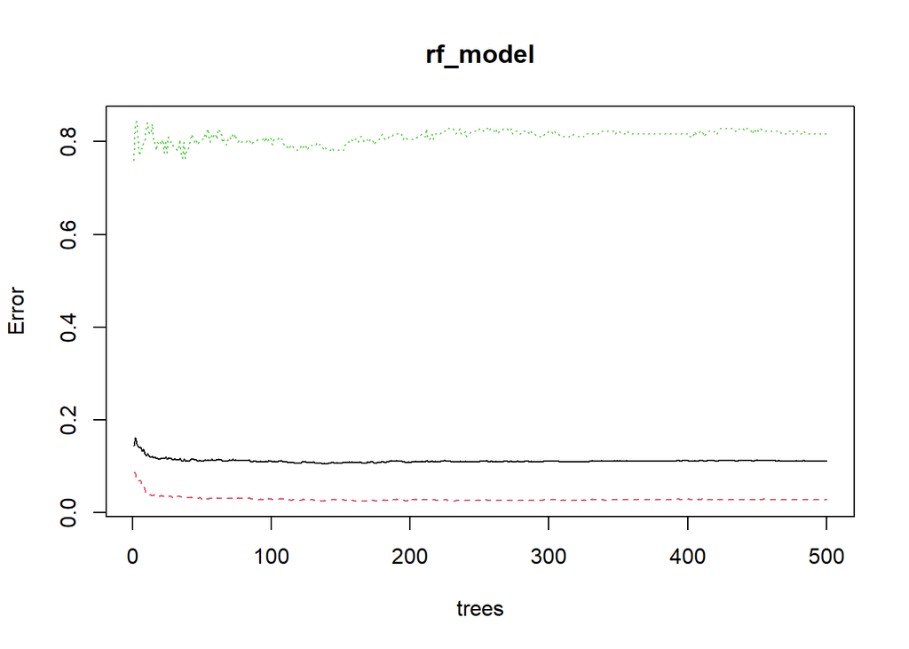

```r
rf_model <- randomForest(as.factor(yyes) ~., data = tele_train)
plot(rf_model)
```

```r
rf_pred <- predict(rf_model, tele_test)

confusionMatrix(as.factor(rf_pred), as.factor(tele_test$yyes), positive = "1")
```

```
## Confusion Matrix and Statistics
##
##           Reference
## Prediction   0   1
##          0 365  30
##          1   9   7
##
##                Accuracy : 0.9051
##                  95% CI : (0.8726, 0.9317)
##     No Information Rate : 0.91
##     P-Value [Acc > NIR] : 0.673611
##
##                   Kappa : 0.2219
##
##  Mcnemar's Test P-Value : 0.001362
##
##             Sensitivity : 0.18919
##             Specificity : 0.97594
##          Pos Pred Value : 0.43750
##          Neg Pred Value : 0.92405
##              Prevalence : 0.09002
##          Detection Rate : 0.01703
##    Detection Prevalence : 0.03893
##       Balanced Accuracy : 0.58256
##
##        'Positive' Class : 1
##
```

```r
# find patterns
randomForest::importance(rf_model)
```

```
##                              MeanDecreaseGini
## age                              32.013757931
## jobadmin.                         5.130272646
## jobblue.collar                    3.388605473
## jobentrepreneur                   1.306955228
## jobhousemaid                      1.047581325
## jobmanagement                     2.801690545
## jobretired                        1.360842987
## jobself.employed                  1.399896279
## jobservices                       2.517339904
## jobstudent                        3.751414180
## jobtechnician                     4.199882451
## jobunemployed                     0.822523663
## jobunknown                        0.600245805
## maritalmarried                    5.105977097
## maritalsingle                     4.738481303
## maritalunknown                    0.009765393
## educationbasic.6y                 2.473871440
## educationbasic.9y                 2.877289007
## educationhigh.school              5.033271053
## educationilliterate               0.000000000
## educationprofessional.course      3.616414782
## educationuniversity.degree        4.808622343
## educationunknown                  2.349370505
## defaultunknown                    4.558759940
## defaultyes                        0.000000000
## housingunknown                    0.947808045
## housingyes                        8.005030426
## loanunknown                       1.011630569
## loanyes                           5.220190842
## contacttelephone                  4.122645987
## monthaug                          2.534641205
## monthdec                          0.707444125
## monthjul                          1.505019973
## monthjun                          1.950165957
## monthmar                          2.074859842
## monthmay                          2.056687981
## monthnov                          1.387339163
## monthoct                          1.410691578
## monthsep                          1.163461743
## day_of_weekmon                    5.170166235
## day_of_weekthu                    4.388933519
## day_of_weektue                    4.658401132
## day_of_weekwed                    5.616550971
## campaign                         15.055283160
## previous                          4.735379545
## poutcomenonexistent               3.078404971
## poutcomesuccess                   5.344614071
## emp.var.rate                      9.308760753
## cons.price.idx                   10.150746345
## cons.conf.idx                    11.421741795
## euribor3m                        34.184551441
## nr.employed                      17.338664002
## pdaysdummy                        5.038711661
```

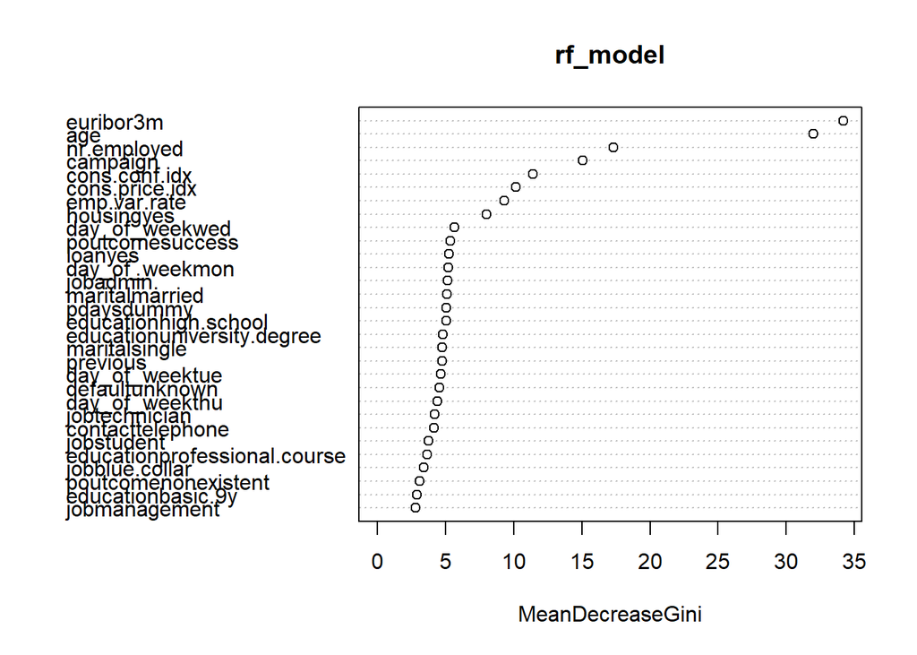

```r
randomForest::varImpPlot(rf_model)
```

# 6. Improve models

## 6.1 Try different K for KNN

```r
# when k=40, Accuracy=0.91
knn_pred_1 <- knn(train = KNN_train, test = KNN_test, cl = KNN_train_label, k = 37)
#knn_pred_2 <- knn(train = KNN_train, test = KNN_test, cl = KNN_train_label, k = 58)

confusionMatrix(as.factor(knn_pred_1), as.factor(KNN_test_label), positive = "1")
```

```
## Confusion Matrix and Statistics
##
##           Reference
## Prediction   0   1
##          0 374  36
##          1   0   1
##
##                Accuracy : 0.9124
##                  95% CI : (0.8808, 0.9379)
##     No Information Rate : 0.91
##     P-Value [Acc > NIR] : 0.475
##
##                   Kappa : 0.0481
##
##  Mcnemar's Test P-Value : 5.433e-09
##
##             Sensitivity : 0.027027
##             Specificity : 1.000000
##          Pos Pred Value : 1.000000
##          Neg Pred Value : 0.912195
##              Prevalence : 0.090024
##          Detection Rate : 0.002433
##    Detection Prevalence : 0.002433
##       Balanced Accuracy : 0.513514
##
##        'Positive' Class : 1
##
```

```r
#confusionMatrix(as.factor(knn_pred_2), as.factor(KNN_test_label), positive = "1")
```

## 6.2 Use the Caret Train function to auto tune Decision Tree and pick the best

```r
# automated parameter tuning of C5.0 decision tree
DT_tune_model <- train(as.factor(yyes) ~., data = tele_train, method = "C5.0")
DT_tune_model
```

```
## C5.0
##
## 1648 samples
##   53 predictor
##    2 classes: '0', '1'
##
## No pre-processing
## Resampling: Bootstrapped (25 reps)
## Summary of sample sizes: 1648, 1648, 1648, 1648, 1648, 1648, ...
## Resampling results across tuning parameters:
##
##   model  winnow  trials  Accuracy   Kappa
##   rules  FALSE    1      0.8859591  0.2017696
##   rules  FALSE   10      0.8894503  0.1817713
##   rules  FALSE   20      0.8895659  0.1770010
##   rules   TRUE    1      0.8892458  0.1983568
##   rules   TRUE   10      0.8890868  0.1824407
##   rules   TRUE   20      0.8900233  0.1951081
##   tree   FALSE    1      0.8824635  0.2015858
##   tree   FALSE   10      0.8895860  0.2103824
##   tree   FALSE   20      0.8892301  0.2020844
##   tree    TRUE    1      0.8834759  0.1926674
##   tree    TRUE   10      0.8872928  0.2017777
##   tree    TRUE   20      0.8889524  0.2001815
##
## Accuracy was used to select the optimal model using the largest value.
## The final values used for the model were trials = 20, model = rules and
##  winnow = TRUE.
```

```r
# apply the best C5.0 candidate model to make predictions
DT_tune_pred <- predict(DT_tune_model, tele_test)
confusionMatrix(as.factor(DT_tune_pred), as.factor(tele_test$yyes), positive = "1")
```

```
## Confusion Matrix and Statistics
##
##           Reference
## Prediction   0   1
##          0 374  37
##          1   0   0
##
##                Accuracy : 0.91
##                  95% CI : (0.878, 0.9358)
##     No Information Rate : 0.91
##     P-Value [Acc > NIR] : 0.5436
##
##                   Kappa : 0
##
##  Mcnemar's Test P-Value : 3.252e-09
##
##             Sensitivity : 0.00000
##             Specificity : 1.00000
##          Pos Pred Value :     NaN
##          Neg Pred Value : 0.90998
##              Prevalence : 0.09002
##          Detection Rate : 0.00000
##    Detection Prevalence : 0.00000
##       Balanced Accuracy : 0.50000
##
##        'Positive' Class : 1
##
```

## 6.3 Use the Caret Train function for auto-tune a boosted customized C5.0 Decision Tree

```r
# customized
grid_c50 <- expand.grid(.model = "tree",
                        .trials = c(10, 20, 30, 40),
                        .winnow = "FALSE")

ctrl <- trainControl(method = "cv", number = 10,
                     selectionFunction = "oneSE")

# auto-tune model
DT_tune_model_customized <- train(as.factor(yyes) ~., data = tele_train, method = "C5.0",
                metric = "Kappa", trControl = ctrl,
               tuneGrid = grid_c50)
DT_tune_customized_pred <- predict(DT_tune_model_customized, tele_test)

# evaluation
confusionMatrix(as.factor(DT_tune_customized_pred), as.factor(tele_test$yyes), positive = "1")
```

```
## Confusion Matrix and Statistics
##
##           Reference
## Prediction   0   1
##          0 363  30
##          1  11   7
##
##                Accuracy : 0.9002
##                  95% CI : (0.8671, 0.9275)
##     No Information Rate : 0.91
##     P-Value [Acc > NIR] : 0.783808
##
##                   Kappa : 0.2079
##
##  Mcnemar's Test P-Value : 0.004937
##
##             Sensitivity : 0.18919
##             Specificity : 0.97059
##          Pos Pred Value : 0.38889
##          Neg Pred Value : 0.92366
##              Prevalence : 0.09002
##          Detection Rate : 0.01703
##    Detection Prevalence : 0.04380
##       Balanced Accuracy : 0.57989
##
##        'Positive' Class : 1
##
```

# 7. Stacked Model

```r
stack_model <- data.frame(log_pred, knn_pred_1, ann_pred, DT_tune_pred, rf_pred, tele_test$yyes)
colnames(stack_model) <- c("logi_reg", "tuned_KNN", "ANN", "tuned_DT", "Random Forest", "True_yyes")

summary(stack_model)
```

```
##     logi_reg         tuned_KNN      ANN          tuned_DT Random Forest
##  Min.   :0.0000004   0:410     Min.   :0.05688   0:411    0:395
##  1st Qu.:0.0348261   1:  1     1st Qu.:0.05688   1:  0    1: 16
##  Median :0.0541030             Median :0.05688
##  Mean   :0.1123127             Mean   :0.11402
##  3rd Qu.:0.1061726             3rd Qu.:0.05688
##  Max.   :0.9148218             Max.   :0.76505
##    True_yyes
##  Min.   :0.00000
##  1st Qu.:0.00000
##  Median :0.00000
##  Mean   :0.09002
##  3rd Qu.:0.00000
##  Max.   :1.00000
```

```r
str(stack_model)
```

```
## 'data.frame':    411 obs. of  6 variables:
##  $ logi_reg     : num  0.2457 0.0144 0.0691 0.3272 0.1132 ...
##  $ tuned_KNN    : Factor w/ 2 levels "0","1": 1 1 1 1 1 1 1 1 1 1 ...
##  $ ANN          : num  0.0569 0.0569 0.0569 0.7642 0.0569 ...
##  $ tuned_DT     : Factor w/ 2 levels "0","1": 1 1 1 1 1 1 1 1 1 1 ...
##  $ Random Forest: Factor w/ 2 levels "0","1": 1 1 1 1 1 1 1 1 1 1 ...
##  $ True_yyes    : num  1 0 0 0 0 0 0 0 0 0 ...
```

# 8. Break stack model data frame into test and train, and do decision tree

```r
set.seed(12345)

test_set <- sample(1:nrow(stack_model), 0.2*nrow(stack_model))

stack_model_train <- stack_model[-test_set, ]
stack_model_test <- stack_model[test_set, ]

str(stack_model_train)
```

```
## 'data.frame':    329 obs. of  6 variables:
##  $ logi_reg     : num  0.2457 0.0144 0.0691 0.3272 0.023 ...
##  $ tuned_KNN    : Factor w/ 2 levels "0","1": 1 1 1 1 1 1 1 1 1 1 ...
##  $ ANN          : num  0.0569 0.0569 0.0569 0.7642 0.0569 ...
##  $ tuned_DT     : Factor w/ 2 levels "0","1": 1 1 1 1 1 1 1 1 1 1 ...
##  $ Random Forest: Factor w/ 2 levels "0","1": 1 1 1 1 1 1 1 1 1 1 ...
##  $ True_yyes    : num  1 0 0 0 0 0 0 0 1 0 ...
```

```r
# model
stack_model_DT <- C5.0(as.factor(True_yyes)~., stack_model_train)

stack_model_pred <- predict(stack_model_DT, stack_model_test)

confusionMatrix(stack_model_pred, as.factor(stack_model_test$True_yyes), positive = "1")
```

```
## Confusion Matrix and Statistics
##
##           Reference
## Prediction  0  1
##          0 76  6
##          1  0  0
##
##                Accuracy : 0.9268
##                  95% CI : (0.8475, 0.9727)
##     No Information Rate : 0.9268
##     P-Value [Acc > NIR] : 0.60638
##
##                   Kappa : 0
##
##  Mcnemar's Test P-Value : 0.04123
##
##             Sensitivity : 0.00000
##             Specificity : 1.00000
##          Pos Pred Value :     NaN
##          Neg Pred Value : 0.92683
##              Prevalence : 0.07317
##          Detection Rate : 0.00000
##    Detection Prevalence : 0.00000
##       Balanced Accuracy : 0.50000
##
##        'Positive' Class : 1
##
```

```r
library(gmodels)
CrossTable(stack_model_pred, as.factor(stack_model_test$True_yyes), prop.chisq = F,prop.r = F, prop.c = F, prop.t = F)
```

```
##
##
##    Cell Contents
## |-------------------------|
## |                       N |
## |-------------------------|
##
##
## Total Observations in Table:  82
##
##
##                  | as.factor(stack_model_test$True_yyes)
## stack_model_pred |         0 |         1 | Row Total |
## -----------------|-----------|-----------|-----------|
##                0 |        76 |         6 |        82 |
## -----------------|-----------|-----------|-----------|
##     Column Total |        76 |         6 |        82 |
## -----------------|-----------|-----------|-----------|
##
##
```

# 9. Conclusion

## 9.1 Compare the models results

Logistic Regression model： Accuracy : 0.9075 KNN model： Accuracy : 0.91 ANN model：Accuracy : 0.8783 Decision Tree model：Accuracy : 0.8954 Random forest model：Accuracy : 0.9051 Improved KNN model：Accuracy : 0.9124 Improved DT_tune_model：Accuracy : 0.91 stack_model： Accuracy : 0.9268

We can find that our stack model have the highest accuracy.

## 9.2 How to improve the success of the TeleMarketing efforts?

I will improve the marketing call strategy by the stack model result, the Call Center will ONLY call those customers that stack model classify as likely to be successful, i.e. who are predicted as “will buy the service” rather than calling all the customers.

According to the Cost Assumption, it costs 1 dollar to make each call, and every successful call results in a net profit of 8 dollar. Because of the computing power limit, the sample is too small, but we can still find the pattern that: If we call all the customers, will lose (6*8-82)= -34 dollars, but if we follow the model, we do not call this 82 people, will save this 34 dollars for call center. If we have larger sample, the call center will even save more money and maximize their net profit.